# Global Patterns of Multidimensional Poverty

This repository contains all files and code to reproduce the findings of the paper “Global Patterns of Multidimensional Poverty: a Markov network approach to deprivation interlinkages analysis”, by Girela, I., García Arancibia, R. & Koplin, E.

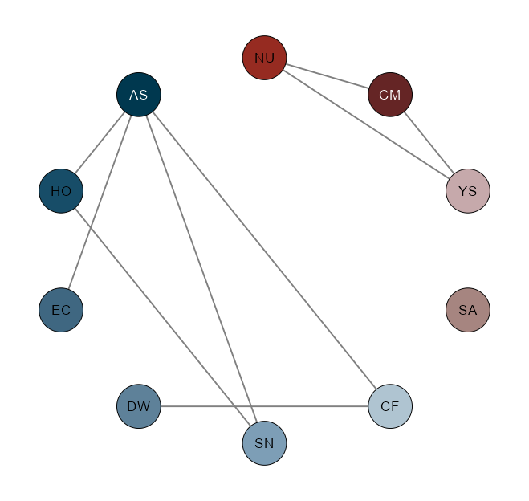

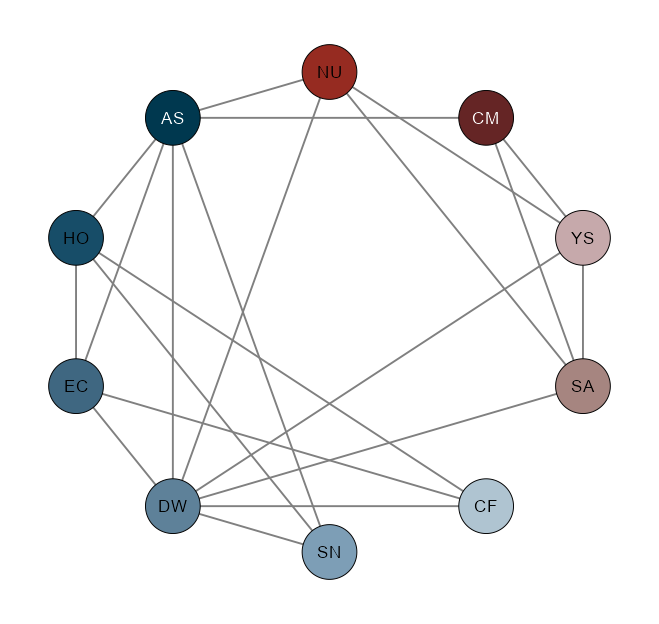

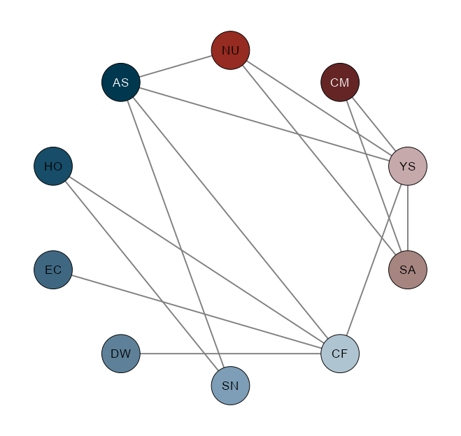

Argentina

Ethiopia

Thailand

### Abstract

This paper introduces a novel graph-based framework, leveraging discrete Markov networks, to analyze the intricate interlinkages among multidimensional poverty indicators. Addressing limitations of existing approaches that often overlook higher-order interactions and rely on restrictive positivity assumptions, our model explicitly represents complex dependencies and accommodates structural zeros prevalent in real-world poverty data. We apply this framework to global MPI data from 63 developing countries, revealing key patterns of conditional dependencies between deprivations and quantifying the influence of individual indicators within the network. By comparing countries with similar overall MPI scores, we demonstrate the model’s ability to uncover distinct underlying patterns of deprivation interlinkages, insights often masked by traditional MPI decomposition. This approach offers a more nuanced and policy-relevant tool for understanding the multifaceted nature of poverty and designing more effective, integrated interventions.

### Explore our findings using the Shiny app!

Ready to dive in and explore the findings yourself? This guide will walk you through the steps to reproduce everything.

##### **Step 1: Get the Code**

First, you’ll need to clone the project repository.

1. **Choose a Destination:** Open your terminal or command prompt and navigate to the directory where you’d like to download the project files. For example, on Windows, you might use:

   `cd C:/Users/YourUsername/Documents`

(Replace “YourUsername” with your actual username.)

2. **Verify Git Installation:** Before cloning, let’s quickly check if Git is installed on your system. Run the following command in your terminal:

   `git --version`

If Git is installed, you’ll see its version information. If not, you’ll need to install it. You can download Git from https://git-scm.com/downloads. Follow the installation instructions for your operating system.

3. **Clone the Repository:** Now, let’s download the project files. Use the following command, which will create a new folder named `DiscreteMarkovNetworkMPI` in your chosen directory:

   `git clone https://github.com/girelaignacio/DiscreteMarkovNetworkMPI.git`

##### **Step 2: Launch the Application**

Once the repository is cloned, you can run the application to explore the findings.

1. **Navigate to the App Folder:** Open the newly created `DiscreteMarkovNetworkMPI` folder and then navigate into the `app` subfolder.
2. **Open `app.R`:** Locate the file named `app.R` within the `/app` folder and open it using RStudio or your preferred R environment.
3. **Run the App:** In your R environment, execute the code within the `app.R` file. This will launch the application, allowing you to interact with the findings directly!

[figure not shown]